# Data Mining Final Project : Music Miner

## Authors:

Ruoyu (Michael) Zhang

Snigdha Potluri

Yifan (Frank) Zhou

# Contents

## Part 1. Introduction: Data and Problem summary

## Part 2. Answering First two quetions with dataset 1

2.1 Exploratory Data Analysis

2.2 Methodology

2.3 Model Tuning and Validation

2.4 Key Takeaway From This Question

## Part 3. Answering another two quetions with dataset 2

3.1 Exploratory Data Analysis

3.2 Methodology

3.3 Models for Question 3: Is there a better cluster way to capture the features of the music?

3.4 Model for Question 4：Are there any country-specific music preferences?

3.5 Key Takeaway From This Question

## Part 4: Conclusions and Discussions Addressing Questions

## Part 5: Future work

# Part 1. Introduction: Data and Problem summary

## Question Addressed:

Question 1: What songs can make it to the top 10 on the billboard?

Question 2: Which artists could create songs that reached the billboard?

Question 3: Is there a better cluster way to capture the features of the music?

Question 4：Are there any country-specific music preferences?

## Dataset Summary

### Dataset 2

This dataset includes the top songs by country by spotify in 2019. This dataset has several variables about the songs and is based on Billboard. The extraction was done at Christmas time, so the most played songs should be related to Christmas. There are 13 attributes of these songs to be explored, including title, artist, top genre, time added, etc.

### url:

https://www.kaggle.com/leonardopena/top-50-spotify-songs-by-each-country

### Decision to keeping both the datasets separate:

We want to keep the datasets sepatate. For this dataset, we have 7000 values, which includes all the songs which made it to the Top 10 of the Billboard Hot 100 Chart from 1990-2010 plus a sample of additional songs that didn't make the Top 10. From Dataset 1, we want to build a model that can predict whether the song can make it to the top 10 on the billboard or not. Possible solutions include classification and regression.

Dataset 2 mainly has Christmas Songs from different regions which we wanted to deal with separately. More regarding this explained in that notebook.

# Part 2. Answering First two quetions with dataset 1

## Question 1: What songs can make it to the top 10 on the billboard?

## Question 2: Which artists could create songs that reached the billboard?

## 2.1 Exploratory Data Analysis

```
<class 'pandas.core.frame.DataFrame'>
RangeIndex: 7574 entries, 0 to 7573
Data columns (total 39 columns):
 #   Column                    Non-Null Count  Dtype
---  ------                    --------------  -----
 0   year                      7574 non-null   int64
 1   songtitle                 7574 non-null   object
 2   artistname                7574 non-null   object
 3   songID                    7574 non-null   object
 4   artistID                  7574 non-null   object
 5   timesignature             7574 non-null   int64
 6   timesignature_confidence  7574 non-null   float64
 7   loudness                  7574 non-null   float64
 8   tempo                     7574 non-null   float64
 9   tempo_confidence          7574 non-null   float64
```

[output cut: 32 more lines]

#### We can notice that no null values were detected in this particular dataset.

```
The number of rows are  7574
The number of columns are 39
```

#### Checking the Correlation between quantitive variables before dropping the columns

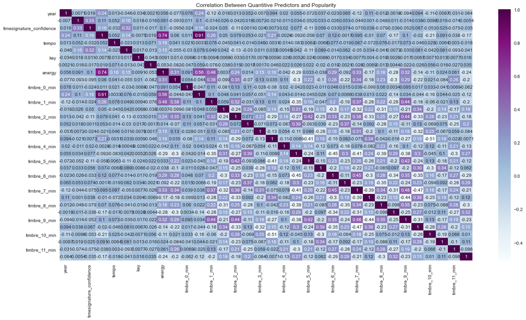

### Since there are 4 columns with categorical data, it will be difficult to analyse the same. Hence we tried to encode these four columns into numerical values.

### Visualization to get insights into the data

Plots - Barplots, Boxplot and a heat map have been plotted.

#### Distribution for different variables

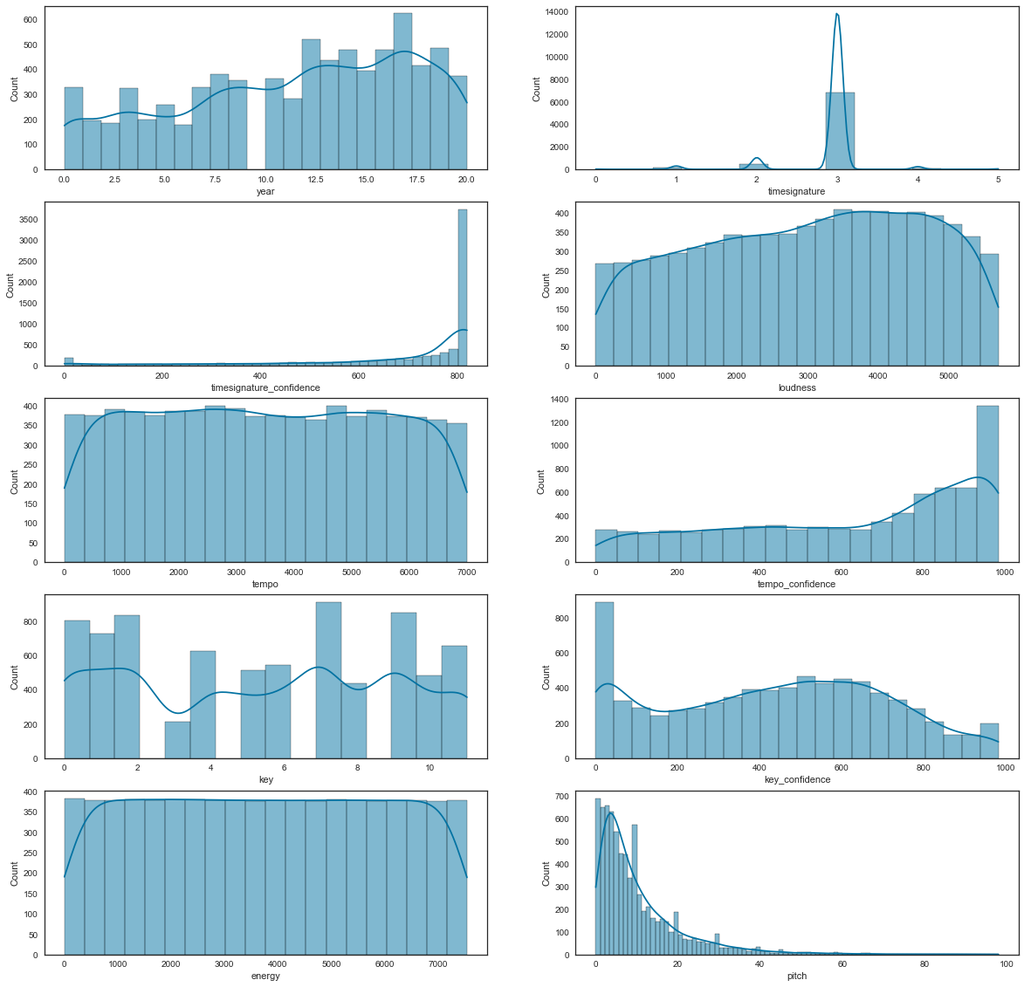

#### Correlation between quantitive variables

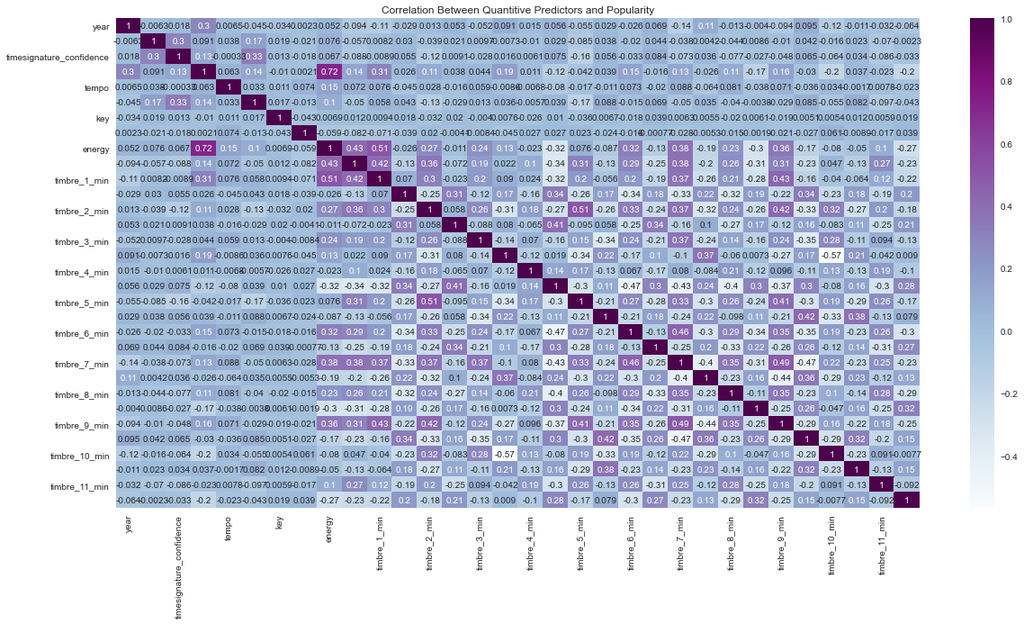

#### Predictors for different keys

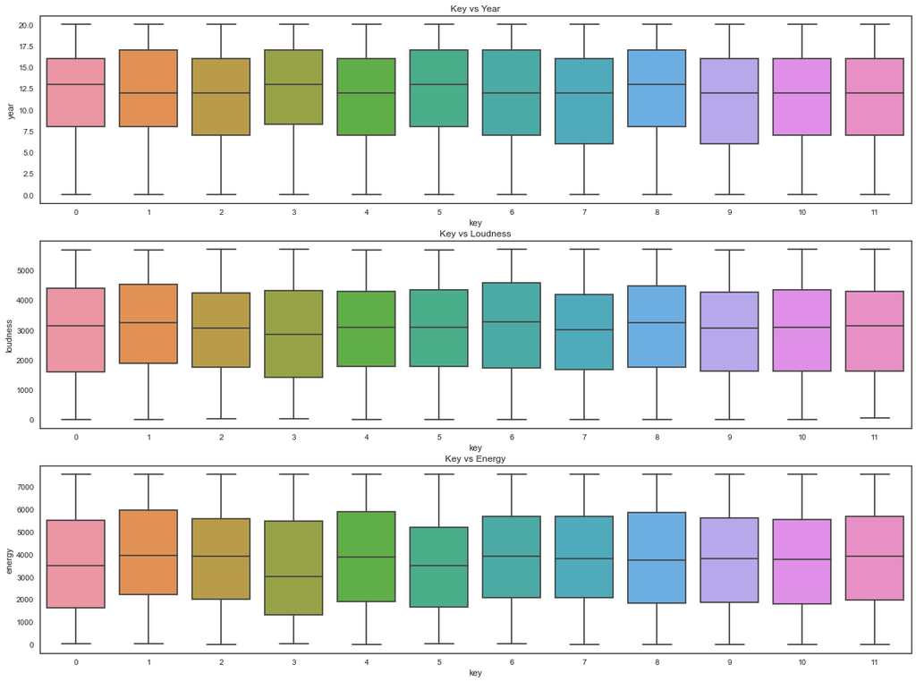

#### Predictors for different timesignatures

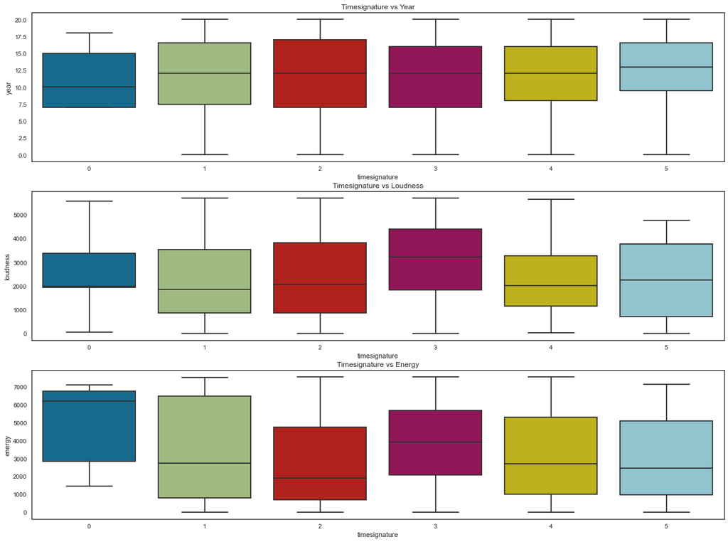

### These boxplots show us the trends of the time of songs with respect to variables over a span of 20 years. We can understand that with the change in loudness and energy, the time of the song changes quite a lot but over the years, the time has stayed pretty standard.

#### Analysis for the first 2 Questions

|  | year | songtitle | artistname | songID | artistID | timesignature | timesignature_confidence | loudness | tempo | tempo_confidence | ... | timbre_7_max | timbre_8_min | timbre_8_max | timbre_9_min | timbre_9_max | timbre_10_min | timbre_10_max | timbre_11_min | timbre_11_max | Top10 |
| --- | --- | --- | --- | --- | --- | --- | --- | --- | --- | --- | --- | --- | --- | --- | --- | --- | --- | --- | --- | --- | --- |
| 9 | 2010 | Whataya Want From Me | Adam Lambert | SOFOBLL13A9E22142F | ARIGTAO11FED0C4411 | 4 | 0.938 | -15.557 | 95.904 | 0.929 | ... | 99.150 | -69.346 | 56.233 | -94.733 | 62.789 | -102.870 | 65.328 | -48.411 | 47.376 | 1 |
| 23 | 2010 | We Are The World 25: For Haiti | Artists For Haiti | SOTEGEI13134389BC0 | ARZAYIQ1275322AEE7 | 4 | 1.000 | -6.218 | 75.018 | 0.232 | ... | 73.640 | -66.116 | 70.950 | -50.593 | 55.819 | -108.325 | 51.494 | -62.202 | 55.321 | 1 |
| 24 | 2010 | Magic | B.o.B | SOCRJPX135FFE4F1AC | ARKQQZA12086C116FC | 4 | 1.000 | -4.281 | 82.543 | 0.948 | ... | 86.738 | -66.377 | 45.026 | -51.316 | 76.215 | -74.426 | 64.825 | -60.809 | 45.137 | 1 |
| 25 | 2010 | Airplanes | B.o.B | SOVWJTF13B346C89A9 | ARKQQZA12086C116FC | 4 | 1.000 | -4.632 | 93.041 | 0.943 | ... | 109.932 | -58.905 | 41.963 | -49.356 | 71.626 | -110.716 | 50.365 | -44.384 | 29.936 | 1 |
| 26 | 2010 | Nothin' On You | B.o.B | SOWHVEZ13672C4B6A4 | ARKQQZA12086C116FC | 4 | 1.000 | -4.310 | 104.015 | 1.000 | ... | 80.755 | -60.000 | 47.343 | -68.064 | 55.142 | -97.047 | 50.844 | -51.398 | 43.509 | 1 |
| ... | ... | ... | ... | ... | ... | ... | ... | ... | ... | ... | ... | ... | ... | ... | ... | ... | ... | ... | ... | ... | ... |
| 7535 | 1990 | The Way You Do The Things You Do | UB40 | SOBYHAX1311AFDCA86 | AR1WWVL1187B9B0306 | 4 | 1.000 | -9.914 | 80.865 | 0.941 | ... | 59.647 | -45.392 | 78.779 | -48.077 | 60.752 | -71.797 | 38.005 | -43.463 | 38.201 | 1 |
| 7536 | 1990 | Ice Ice Baby | Vanilla Ice | SOJFSMW13741A466BA | ARQUN9K1187B9B5BD7 | 4 | 0.326 | -9.894 | 115.478 | 0.571 | ... | 149.028 | -64.857 | 71.936 | -96.373 | 87.181 | -90.330 | 45.489 | -71.101 | 42.939 | 1 |
| 7543 | 1990 | Cherry Pie | Warrant | SOCHOMY13743D265F0 | AR261YW1187FB374B3 | 4 | 0.712 | -4.324 | 88.066 | 0.288 | ... | 134.903 | -82.790 | 53.873 | -49.426 | 97.366 | -194.978 | 136.589 | -49.064 | 42.615 | 1 |
| 7544 | 1990 | Release Me | Wilson Phillips | SOQNRIS13167715B05 | ARY2W5X1187FB3CB7A | 4 | 1.000 | -11.634 | 97.217 | 0.914 | ... | 116.012 | -64.832 | 53.894 | -55.841 | 69.711 | -97.623 | 58.941 | -52.319 | 65.427 | 1 |
| 7545 | 1990 | Hold On | Wilson Phillips | SOLLKZM13775574E9D | ARY2W5X1187FB3CB7A | 4 | 0.973 | -7.034 | 97.808 | 0.976 | ... | 51.859 | -71.843 | 51.896 | -52.159 | 57.414 | -65.007 | 57.240 | -55.734 | 54.569 | 1 |

1119 rows × 39 columns

```
The singer with most number of songs in the database:  will.i.am
The singer with most number Top10 of songs:  matchbox twenty
```

## 2.2 Methodology

## Classification

The classification/prediction variable would be the Top10 coulmn, which defines whether the song falls under the top 10 category on the Billboard or not. This is listed as a binary value and hence was chosen as the prediction variable.

### Pre-liminary tests

#### KNN Classification

```
[[1878   91]
 [ 255   49]]
              precision    recall  f1-score   support

           0      0.880     0.954     0.916      1969
           1      0.350     0.161     0.221       304

    accuracy                          0.848      2273
   macro avg      0.615     0.557     0.568      2273
weighted avg      0.810     0.848     0.823      2273

Accuracy Score:  0.847778266608007
```

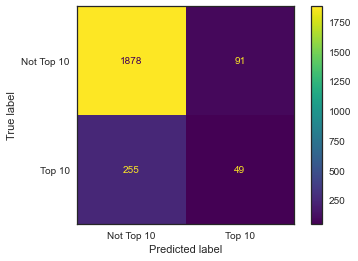

### We've trained the model with KNN Classifier as my priliminary test and the accuracy score seems to be pretty good with 84.8% accuracy.

#### Naive Bayes Classification

```
              precision    recall  f1-score   support

           0      0.929     0.728     0.816      1969
           1      0.266     0.638     0.376       304

    accuracy                          0.716      2273
   macro avg      0.597     0.683     0.596      2273
weighted avg      0.840     0.716     0.757      2273

Accuracy Score:  0.7162340519137703
```

```
<sklearn.metrics._plot.confusion_matrix.ConfusionMatrixDisplay at 0x25014de4730>
```

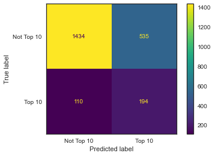

#### Interpretation based on preliminary tests:

--> Comparing both the models, it is clear that the KNN model is performing better than the Naive Bayes model. Since we have classfied using only Top 10 Score, this is not a multiple class dataset, Naive Bayes classification is not performing better compared to K-nearest neighbors.

--> The reason for KNN is working well can be that the data per class is spread evenly across the feature space and thus it is easy to fit classifier based on nearest neighbor majority voting.

--> The model classification is good since an 84% is very goood value but it can be noticed that the precision values are not top-notch for the Top 10 values predicted. This is due to the imbalance in the data. We plan on building better models to try and classify the imbalanced data further.

# 2.3 Model Tuning and Validation

### 2.3.1. Logistic Regression Classifier Model

```
Training target statistics: Counter({'Top10': 1})
Testing target statistics: Counter({'Top10': 1})
                   pre       rec       spe        f1       geo       iba       sup

          0       0.94      0.72      0.70      0.81      0.71      0.51      1969
          1       0.28      0.70      0.72      0.40      0.71      0.51       304

avg / total       0.85      0.72      0.71      0.76      0.71      0.51      2273
```

|  | Accuracy | Balanced accuracy |
| --- | --- | --- |
| Dummy classifier | 0.846255 | 0.5 |

### Approach Methodology

Before training a the model, we stored the results obtained with our Dummy Classifier.

We then created a pipeline using a LogisticRegression classifier using one-hot encoding of the categorical columns and standardized the numerical columns before pushing the data into the LogisticRegression classifier. We defined the categorical and numerical pipelines and created a preprocessor which will dispatch the categorical columns to the categorical pipeline and the numerical columns to the numerical pipeline.

Finally connected the preprocessor with our LogisticRegression classifier and then evaluated the model.

### LogisticRegression Classifier

|  | Accuracy | Balanced accuracy |
| --- | --- | --- |
| Dummy classifier | 0.846255 | 0.500000 |
| Logistic regression | 0.851727 | 0.564984 |

```
[[1920   49]
 [ 250   54]]
              precision    recall  f1-score   support

           0      0.885     0.975     0.928      1969
           1      0.524     0.178     0.265       304

    accuracy                          0.868      2273
   macro avg      0.705     0.576     0.597      2273
weighted avg      0.837     0.868     0.839      2273
```

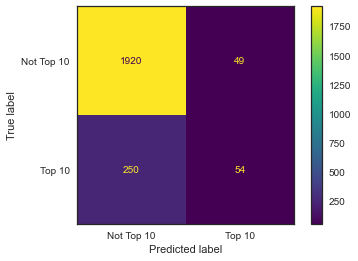

### Quite a bit of difference can be noticed with respect to precision with our LR model.

### 2.3.2 RandomForest Classifier

|  | Accuracy | Balanced accuracy |
| --- | --- | --- |
| Dummy classifier | 0.846255 | 0.500000 |
| Logistic regression | 0.851727 | 0.564984 |
| Random forest | 0.852480 | 0.531290 |

```
[[1958   11]
 [ 281   23]]
              precision    recall  f1-score   support

           0      0.874     0.994     0.931      1969
           1      0.676     0.076     0.136       304

    accuracy                          0.872      2273
   macro avg      0.775     0.535     0.533      2273
weighted avg      0.848     0.872     0.824      2273
```

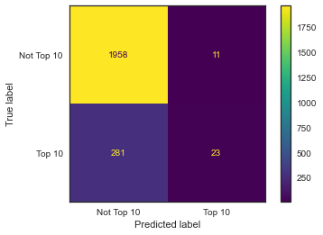

Most of the models in scikit-learn have a parameter class_weight. This parameter will affect the computation of the loss in linear model or the criterion in the tree-based model to penalize differently a false classification from the minority and majority class. We have set class_weight="balanced" such that the weight applied is inversely proportional to the class frequency. We test this parametrization in both linear model and tree-based model.

### 2.3.3.Model Tuning with balanced Class Weights

|  | Accuracy | Balanced accuracy |
| --- | --- | --- |
| Dummy classifier | 0.846255 | 0.500000 |
| Logistic regression | 0.851727 | 0.564984 |
| Random forest | 0.852480 | 0.531290 |
| Logistic regression with balanced class weights | 0.697794 | 0.710496 |

```
[[1359  610]
 [  73  231]]
              precision    recall  f1-score   support

           0      0.949     0.690     0.799      1969
           1      0.275     0.760     0.403       304

    accuracy                          0.700      2273
   macro avg      0.612     0.725     0.601      2273
weighted avg      0.859     0.700     0.746      2273
```

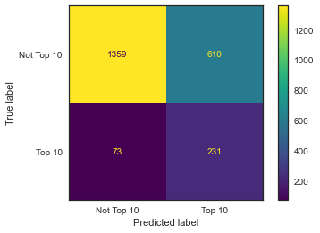

|  | Accuracy | Balanced accuracy |
| --- | --- | --- |
| Dummy classifier | 0.846255 | 0.500000 |
| Logistic regression | 0.851727 | 0.564984 |
| Random forest | 0.852480 | 0.531290 |
| Logistic regression with balanced class weights | 0.697794 | 0.710496 |
| Random forest with balanced class weights | 0.848331 | 0.519802 |

```
[[1960    9]
 [ 290   14]]
              precision    recall  f1-score   support

           0      0.871     0.995     0.929      1969
           1      0.609     0.046     0.086       304

    accuracy                          0.868      2273
   macro avg      0.740     0.521     0.507      2273
weighted avg      0.836     0.868     0.816      2273
```

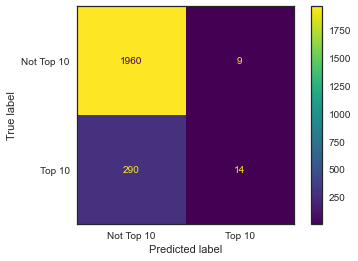

## 2.4 Key Takeaway From This Question

### From the above results, it can be concluded that 1119 songs hit the Billboard Top10 Songs over a period of 20 years.

### Of all the songs, the singer with the most number of songs in this dataset is: will.i.am

### The singer with most number of songs that made it to the Top10 is Matchbox Twenty

# Part 3. Answering another two quetions with dataset 2

## Question 3: Is there a better cluster way to capture the features of the music?

## Question 4：Are there any country-specific music preferences?

## 3.1 Exploratory Data Analysis

|  | title | artist | top genre | year | bpm | nrgy | dnce | dB | live | val | dur | acous | spch | pop | country |
| --- | --- | --- | --- | --- | --- | --- | --- | --- | --- | --- | --- | --- | --- | --- | --- |
| 0 | Dance Monkey | Tones and I | australian pop | 2019 | 98.0 | 59.0 | 82.0 | -6.0 | 15.0 | 51.0 | 209 | 69.0 | 9.0 | 100 | world |
| 1 | ROXANNE | Arizona Zervas | pop rap | 2019 | 117.0 | 60.0 | 62.0 | -6.0 | 46.0 | 46.0 | 164 | 5.0 | 15.0 | 99 | world |
| 2 | Memories | Maroon 5 | pop | 2019 | 91.0 | 32.0 | 76.0 | -7.0 | 8.0 | 57.0 | 189 | 84.0 | 5.0 | 99 | world |
| 3 | Circles | Post Malone | dfw rap | 2019 | 120.0 | 76.0 | 70.0 | -3.0 | 9.0 | 55.0 | 215 | 19.0 | 4.0 | 99 | world |
| 4 | All I Want for Christmas Is You | Mariah Carey | dance pop | 1994 | 150.0 | 63.0 | 34.0 | -7.0 | 7.0 | 35.0 | 241 | 16.0 | 4.0 | 98 | world |

```
There are 20 countries in the dataset. We will get generate several regions.
```

```
array(['world', 'africa', 'argentina', 'australia', 'belgium', 'bolivia',
       'brazil', 'canada', 'germany', 'colombia', 'chile', 'spain', 'usa',
       'france', 'india', 'indonesia', 'israel', 'italy', 'japan',
       'malasya'], dtype=object)
```

### Correlation between quantitive variables

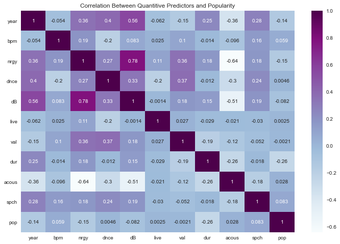

### Predictors for different countries

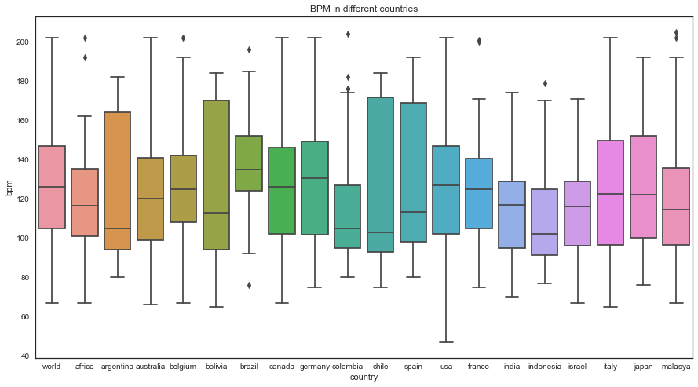

### Most popular genre and artist

```
[(80.0, 100.0)]
```

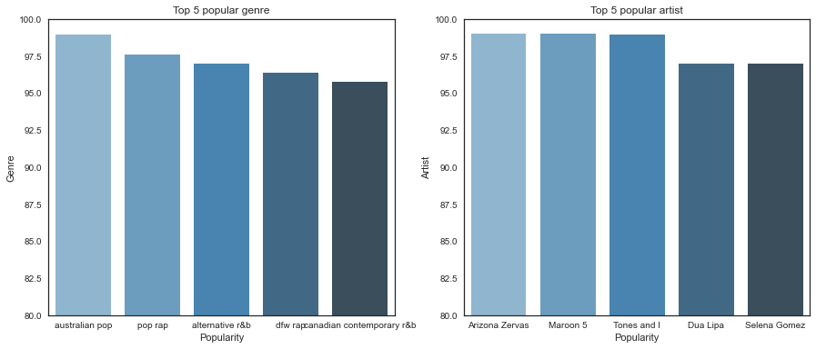

# 3.2 Methodology

For Question 3, we will use k-means to cluster. To determine the number of clusters, we will use the elbow method and calinski_harabasz score to develop models. Finally we will explore the unique features of these clusters.

For Question 4, we will use Naive Bayes for classification and k-means for clustering. To determine important features in certain countries, we will use Principal Component Analysis and Feature Selection to discover country-wise features.

## 3.3 Models for Question 3: Is there a better cluster way to capture the features of the music?

### 3.3.1. Reading and cleaning datasets

The same songs may appear in different countries, so we need to drop the duplicates.

There are 524 unique songs in the dataset.

### 3.3.2 Let's see what the current genre classification is

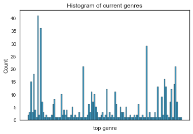

```
-0.3843557721684957
```

There are 66 genres with less than 3 songs in it.This negative silhouette score means the songs in some genres are actually not that different from other genres becasue there are so many genres for the current number of features. Given that we only have 11 features, is there a better classification way to capture the features of the music?

### 3.3.3 PCA

Before moving on to clustering, we will first get to know a little more about the features. We are going to examine the covariance between the features.

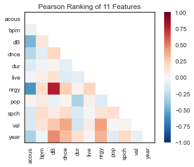

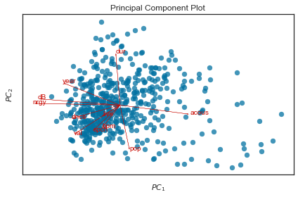

### 3.3.4 Clustering

#### a. Choosing k, evaluating and choosing models

Use kmeans clustering to find genres

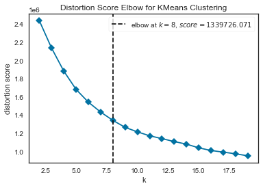

The best k for distortion metric is 8.

Use Calinski Harabasz method to determine number of clusters

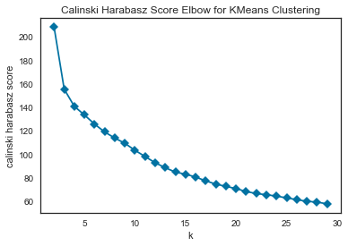

The best k for Calinski Harabasz is 2, different from distorion. Since C-H score computes the ratio between the within-cluster dispersion and the between-cluster dispersion, when clustering is 2, it must be the case that there some really distinctive features between the two classes. We are going to look into both of the models with k = 8 and k = 2.

```
dict_keys(['ax', 'colors', 'estimator', 'is_fitted'])


dict_keys(['ax', 'colors', 'estimator', 'is_fitted'])
```

```
SilhouetteVisualizer(ax=<AxesSubplot:>, colors='yellowbrick',
                     estimator=KMeans(max_iter=10000, n_clusters=2,
                                      random_state=1))
```

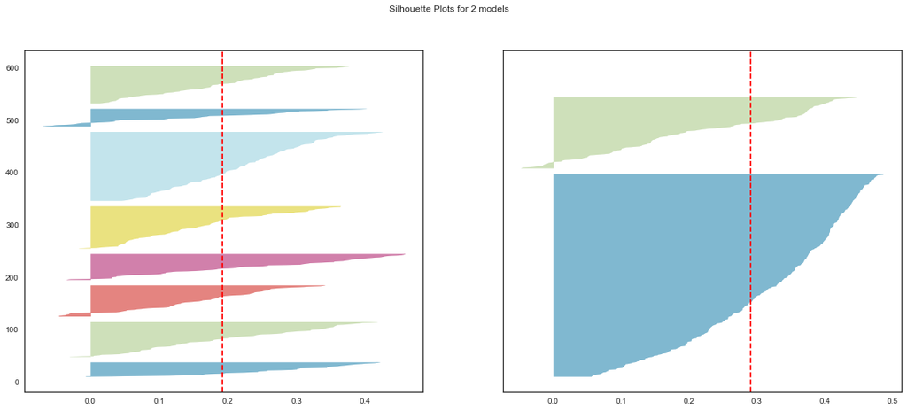

The silhouette values for k = 2 is better than k = 8.

```
dict_keys(['ax', 'embedding', 'estimator', 'is_fitted', 'legend', 'legend_loc', 'legend_size', 'max_size', 'min_size', 'random_state', 'scoring'])


dict_keys(['ax', 'embedding', 'estimator', 'is_fitted', 'legend', 'legend_loc', 'legend_size', 'max_size', 'min_size', 'random_state', 'scoring'])
```

```
InterclusterDistance(ax=<AxesSubplot:>,
                     estimator=KMeans(max_iter=10000, random_state=1))
```

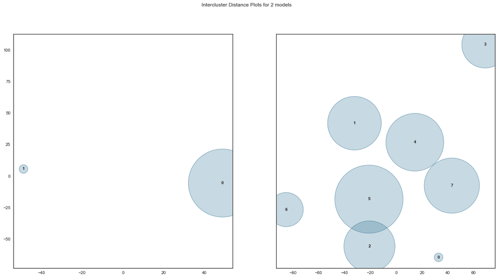

#### b. Insights from model with k = 2

Use Mann-Whitney U Tests to examine whether the distribution of features are different between the clusters; t-test for mean

```
Feature   | Mann-Whitney p-value| t-test p-value
acous     |               0.1026|     0.2718
bpm       |               0.2386|     0.5075
dB        |               0.2223|     0.5853
dnce      |               0.0000|     0.0000
dur       |               0.0000|     0.0000
live      |               0.0639|     0.0446
nrgy      |               0.1137|     0.3087
pop       |               0.0000|     0.0000
spch      |               0.0000|     0.0022
val       |               0.0000|     0.0000
```

When k = 2 clusters, there is significancy difference in dancibility, duration,popularity, speechiness, and valence. Examine the distribution of these features in different clusters.

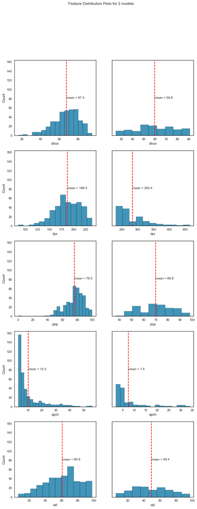

|  | cluster | dnce | dur | pop | spch | val |
| --- | --- | --- | --- | --- | --- | --- |
| 0 | 0 | 67.399485 | 186.53866 | 76.015464 | 10.270619 | 60.865979 |
| 1 | 1 | 59.764706 | 283.375 | 69.757353 | 7.433824 | 49.441176 |

|  | title | artist | top genre | year | bpm | nrgy | dnce | dB | live | val | dur | acous | spch | pop |
| --- | --- | --- | --- | --- | --- | --- | --- | --- | --- | --- | --- | --- | --- | --- |
| 0 | Dance Monkey | Tones and I | australian pop | 2019 | 98.0 | 59.0 | 82.0 | -6.0 | 15.0 | 51.0 | 209 | 69.0 | 9.0 | 100 |
| 2 | Memories | Maroon 5 | pop | 2019 | 91.0 | 32.0 | 76.0 | -7.0 | 8.0 | 57.0 | 189 | 84.0 | 5.0 | 99 |
| 3 | Circles | Post Malone | dfw rap | 2019 | 120.0 | 76.0 | 70.0 | -3.0 | 9.0 | 55.0 | 215 | 19.0 | 4.0 | 99 |
| 1 | ROXANNE | Arizona Zervas | pop rap | 2019 | 117.0 | 60.0 | 62.0 | -6.0 | 46.0 | 46.0 | 164 | 5.0 | 15.0 | 99 |
| 366 | Lose You To Love Me | Selena Gomez | dance pop | 2019 | 102.0 | 34.0 | 51.0 | -9.0 | 21.0 | 9.0 | 206 | 58.0 | 4.0 | 97 |
| 6 | Falling | Trevor Daniel | alternative r&b | 2018 | 127.0 | 43.0 | 78.0 | -9.0 | 9.0 | 24.0 | 159 | 12.0 | 4.0 | 97 |
| 7 | RITMO (Bad Boys For Life) | The Black Eyed Peas | dance pop | 2019 | 105.0 | 72.0 | 72.0 | -7.0 | 24.0 | 67.0 | 222 | 3.0 | 7.0 | 97 |
| 8 | Don't Start Now | Dua Lipa | dance pop | 2019 | 124.0 | 79.0 | 79.0 | -5.0 | 10.0 | 68.0 | 183 | 1.0 | 8.0 | 97 |
| 123 | bad guy | Billie Eilish | electropop | 2019 | 135.0 | 43.0 | 70.0 | -11.0 | 10.0 | 56.0 | 194 | 33.0 | 38.0 | 96 |

|  | title | artist | top genre | year | bpm | nrgy | dnce | dB | live | val | dur | acous | spch | pop |
| --- | --- | --- | --- | --- | --- | --- | --- | --- | --- | --- | --- | --- | --- | --- |
| 4 | All I Want for Christmas Is You | Mariah Carey | dance pop | 1994 | 150.0 | 63.0 | 34.0 | -7.0 | 7.0 | 35.0 | 241 | 16.0 | 4.0 | 98 |
| 5 | everything i wanted | Billie Eilish | electropop | 2019 | 120.0 | 23.0 | 70.0 | -14.0 | 11.0 | 24.0 | 245 | 90.0 | 10.0 | 98 |
| 62 | China | Anuel AA | latin | 2019 | 105.0 | 81.0 | 79.0 | -4.0 | 8.0 | 61.0 | 302 | 8.0 | 9.0 | 94 |
| 367 | Lucid Dreams | Juice WRLD | chicago rap | 2018 | 84.0 | 57.0 | 51.0 | -7.0 | 34.0 | 22.0 | 240 | 35.0 | 20.0 | 94 |
| 65 | LA CANCIÓN | J Balvin | latin | 2019 | 176.0 | 65.0 | 75.0 | -6.0 | 11.0 | 43.0 | 243 | 15.0 | 32.0 | 93 |
| 67 | Callaita | Bad Bunny | latin | 2019 | 176.0 | 62.0 | 61.0 | -5.0 | 24.0 | 24.0 | 251 | 60.0 | 31.0 | 92 |
| 66 | Adicto (with Anuel AA & Ozuna) | Tainy | pop reggaeton | 2019 | 80.0 | 84.0 | 73.0 | -5.0 | 18.0 | 62.0 | 271 | 2.0 | 7.0 | 92 |
| 370 | Mean It | Lauv | pop | 2019 | 96.0 | 45.0 | 75.0 | -9.0 | 17.0 | 34.0 | 233 | 4.0 | 9.0 | 89 |
| 76 | Hola - Remix | Dalex | latin | 2019 | 182.0 | 67.0 | 65.0 | -6.0 | 8.0 | 34.0 | 250 | 47.0 | 31.0 | 89 |

|  | cluster | dnce | dur | pop | spch | val |
| --- | --- | --- | --- | --- | --- | --- |
| 0 | 0 | 67.399485 | 186.53866 | 76.015464 | 10.270619 | 60.865979 |
| 1 | 1 | 59.764706 | 283.375 | 69.757353 | 7.433824 | 49.441176 |

|  | title | artist | top genre | year | bpm | nrgy | dnce | dB | live | val | dur | acous | spch | pop |
| --- | --- | --- | --- | --- | --- | --- | --- | --- | --- | --- | --- | --- | --- | --- |
| 0 | Dance Monkey | Tones and I | australian pop | 2019 | 98.0 | 59.0 | 82.0 | -6.0 | 15.0 | 51.0 | 209 | 69.0 | 9.0 | 100 |
| 2 | Memories | Maroon 5 | pop | 2019 | 91.0 | 32.0 | 76.0 | -7.0 | 8.0 | 57.0 | 189 | 84.0 | 5.0 | 99 |
| 3 | Circles | Post Malone | dfw rap | 2019 | 120.0 | 76.0 | 70.0 | -3.0 | 9.0 | 55.0 | 215 | 19.0 | 4.0 | 99 |
| 1 | ROXANNE | Arizona Zervas | pop rap | 2019 | 117.0 | 60.0 | 62.0 | -6.0 | 46.0 | 46.0 | 164 | 5.0 | 15.0 | 99 |
| 366 | Lose You To Love Me | Selena Gomez | dance pop | 2019 | 102.0 | 34.0 | 51.0 | -9.0 | 21.0 | 9.0 | 206 | 58.0 | 4.0 | 97 |
| 6 | Falling | Trevor Daniel | alternative r&b | 2018 | 127.0 | 43.0 | 78.0 | -9.0 | 9.0 | 24.0 | 159 | 12.0 | 4.0 | 97 |
| 7 | RITMO (Bad Boys For Life) | The Black Eyed Peas | dance pop | 2019 | 105.0 | 72.0 | 72.0 | -7.0 | 24.0 | 67.0 | 222 | 3.0 | 7.0 | 97 |
| 8 | Don't Start Now | Dua Lipa | dance pop | 2019 | 124.0 | 79.0 | 79.0 | -5.0 | 10.0 | 68.0 | 183 | 1.0 | 8.0 | 97 |
| 123 | bad guy | Billie Eilish | electropop | 2019 | 135.0 | 43.0 | 70.0 | -11.0 | 10.0 | 56.0 | 194 | 33.0 | 38.0 | 96 |

|  | title | artist | top genre | year | bpm | nrgy | dnce | dB | live | val | dur | acous | spch | pop |
| --- | --- | --- | --- | --- | --- | --- | --- | --- | --- | --- | --- | --- | --- | --- |
| 4 | All I Want for Christmas Is You | Mariah Carey | dance pop | 1994 | 150.0 | 63.0 | 34.0 | -7.0 | 7.0 | 35.0 | 241 | 16.0 | 4.0 | 98 |
| 5 | everything i wanted | Billie Eilish | electropop | 2019 | 120.0 | 23.0 | 70.0 | -14.0 | 11.0 | 24.0 | 245 | 90.0 | 10.0 | 98 |
| 62 | China | Anuel AA | latin | 2019 | 105.0 | 81.0 | 79.0 | -4.0 | 8.0 | 61.0 | 302 | 8.0 | 9.0 | 94 |
| 367 | Lucid Dreams | Juice WRLD | chicago rap | 2018 | 84.0 | 57.0 | 51.0 | -7.0 | 34.0 | 22.0 | 240 | 35.0 | 20.0 | 94 |
| 65 | LA CANCIÓN | J Balvin | latin | 2019 | 176.0 | 65.0 | 75.0 | -6.0 | 11.0 | 43.0 | 243 | 15.0 | 32.0 | 93 |
| 67 | Callaita | Bad Bunny | latin | 2019 | 176.0 | 62.0 | 61.0 | -5.0 | 24.0 | 24.0 | 251 | 60.0 | 31.0 | 92 |
| 66 | Adicto (with Anuel AA & Ozuna) | Tainy | pop reggaeton | 2019 | 80.0 | 84.0 | 73.0 | -5.0 | 18.0 | 62.0 | 271 | 2.0 | 7.0 | 92 |
| 370 | Mean It | Lauv | pop | 2019 | 96.0 | 45.0 | 75.0 | -9.0 | 17.0 | 34.0 | 233 | 4.0 | 9.0 | 89 |
| 76 | Hola - Remix | Dalex | latin | 2019 | 182.0 | 67.0 | 65.0 | -6.0 | 8.0 | 34.0 | 250 | 47.0 | 31.0 | 89 |

#### d. Insights from model with k = 8

Use Kruskal-Wallis H-test to examine whether the distribution of features are different among the clusters

```
Feature   | Kruskal-Wallis p-value
acous     |               0.0000
bpm       |               0.0000
dB        |               0.0000
dnce      |               0.0000
dur       |               0.0000
live      |               0.0000
nrgy      |               0.0000
pop       |               0.0000
spch      |               0.0000
val       |               0.0000
```

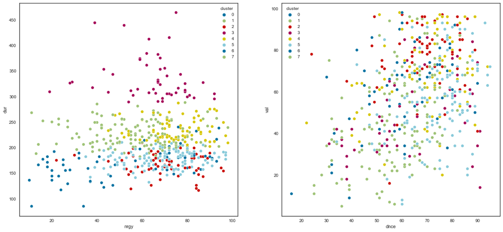

## 3.4 Model for Question 4：Are there any country-specific music preferences?

### An inituitive idea would be classification based on countries. However, classification with countries comes with a poor accuracy.

```
              precision    recall  f1-score   support

      africa       0.11      0.08      0.09        13
   argentina       0.17      0.29      0.22        17
   australia       0.20      0.20      0.20        15
     belgium       0.00      0.00      0.00        14
     bolivia       0.08      0.14      0.10        14
      brazil       0.50      0.83      0.62        12
      canada       0.08      0.20      0.11        15
       chile       0.50      0.08      0.14        12
    colombia       0.25      0.42      0.31        12
      france       0.33      0.23      0.27        13
     germany       0.00      0.00      0.00        12
       india       0.30      0.19      0.23        16
   indonesia       0.24      0.36      0.29        14
      israel       0.75      0.29      0.41        21
       italy       0.00      0.00      0.00        13
       japan       0.55      0.63      0.59        19
     malasya       0.16      0.27      0.20        15
       spain       0.12      0.06      0.08        17
         usa       0.33      0.18      0.23        17

    accuracy                           0.24       281
   macro avg       0.25      0.23      0.22       281
weighted avg       0.26      0.24      0.23       281
```

### Let's choose the countries with high precision to do the classification again. We select Brazil, Israel and Japan and use Naive Bayes to conduct the classification

```
              precision    recall  f1-score   support

      brazil       0.87      0.93      0.90        14
      israel       0.86      0.67      0.75        18
       japan       0.75      0.92      0.83        13

    accuracy                           0.82        45
   macro avg       0.82      0.84      0.82        45
weighted avg       0.83      0.82      0.82        45
```

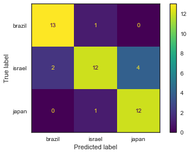

### We could do a clustering to verify our choice.

### First, group the orginal dataset by countries and calculate the mean of each property. Therefore we could know what a popular song in certain countries looks like.

| country | bpm | nrgy | dnce | dB | live | val | dur | acous | spch |
| --- | --- | --- | --- | --- | --- | --- | --- | --- | --- |
| africa | 120.312500 | 53.979167 | 62.750000 | -9.125000 | 18.250000 | 60.187500 | 227.291667 | 40.479167 | 5.583333 |
| argentina | 123.775510 | 73.591837 | 73.551020 | -4.367347 | 17.693878 | 68.530612 | 224.183673 | 20.612245 | 11.346939 |
| australia | 122.469388 | 54.816327 | 56.877551 | -8.428571 | 19.244898 | 63.530612 | 187.877551 | 44.551020 | 5.061224 |
| belgium | 125.755102 | 55.653061 | 58.326531 | -8.367347 | 21.571429 | 62.897959 | 190.102041 | 44.204082 | 5.714286 |
| bolivia | 128.897959 | 69.040816 | 73.408163 | -4.836735 | 14.795918 | 68.183673 | 226.673469 | 22.836735 | 14.836735 |

### Then we do a KMeans clustering for countries based on songs' properties. Since we select three typical countries above, let's set n_cluster = 3 to see the result.

```
country     africa  india  indonesia  israel  malasya
Clustering       0      0          0       0        0
country     argentina  bolivia  chile  colombia  japan  spain
Clustering          1        1      1         1      1      1
country     australia  belgium  brazil  canada  france  germany  italy  usa
Clustering          2        2       2       2       2        2      2    2
```

### We take two approach to discover countrywise features: PCA and Feature Selection.

For PCA we select two principal components and visualize their loadings.

For feature selection we use linear regression model and forward sequential selection. Let's start with Japan.

### PCA and Feature Selection for popular songs in Japan

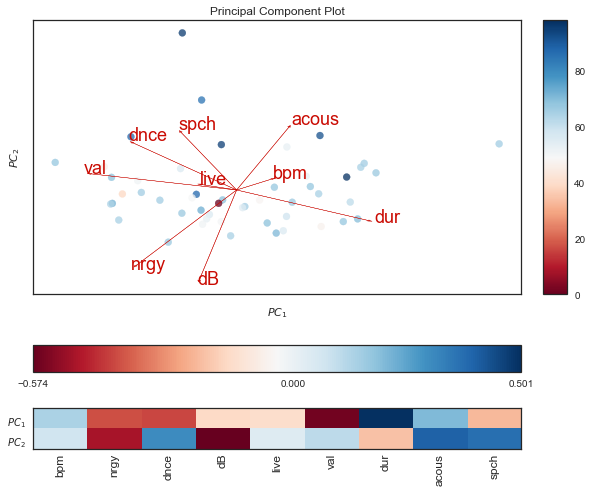

```
Features selected by forward sequential selection for Japan: ['nrgy' 'val' 'spch']
```

### PCA and Feature Selection for popular songs in Israel.

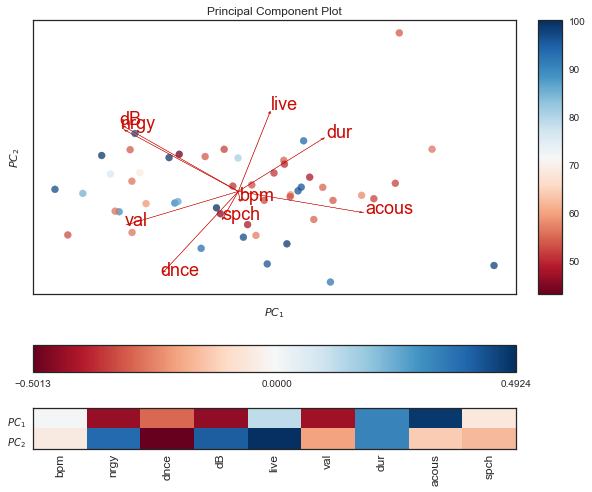

```
Features selected by forward sequential selection for Israel: ['nrgy' 'dur' 'spch']
```

### PCA and Feature Selection for popular songs in Brazil

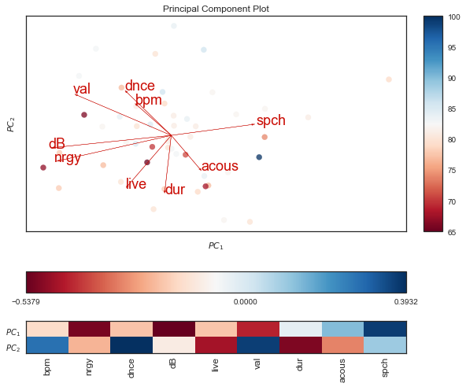

```
Features selected by forward sequential selection for Brazil: ['nrgy' 'dnce' 'live']
```

## Key Takeaway From This Question

# Part 4: Conclusions and Discussions Addressing Questions

#### Question 1: What songs can make it to the top 10 on the billboard?

1119 songs hit the Billboard Top10 Songs over a period of 20 years.

#### Question 2: Which artists could create songs that reached the billboard?

The singer with most number of songs that made it to the Top10 is Matchbox Twenty

#### Question 4：Are there any country-specific music preferences?

There are country-specific preferences. Three typical countries are Japan, Israel and Brazil. Each represents a feature preference.

# Part 5: Future work

## Future work 1:

The clustering methods this project is proposing is based on the features we have. Currently, this dataset only contains a limited number of features. If we have a larger dataset with more features, we will be able to make more delicate clustering, bring new insights into what different genre of music actually mean to people other than the tradition genre method such as hip pop and R&B.

## Future work 2

In Question 4, we use Feature Selection and Pricipal Component Analysis to decide what features are important in different countries. However, the result of SFS and PCA does not always correspond with each other. An important future work would be to discover the reason behind it and try other methods for feature imporance.